# Vignette Processing Speed Package & Symbol Search app

In this vignette, I discuss the functionality of *Symbol-Search* App and the package *ProcessingSpeed*, which contains a small symbol search game that can measure the users relative processing speed.

## Generating Items for the Game

If you run the symbols-app it automatically generates 60 items for the game, but you can increase or decrease this number by changing the only parameter `nr_items` of `GenerateItems()` to a different number. This function then creates a list of the specified number of items, with a string of answers and the relative positions of the answers in relation to the buttons on the screen. See below.

```r
my_items <- GenerateItems(nr_items = 5)
my_items
```

```
#> $items
#> $items$item_1
#> [1]  4  2 13  2 16  8 12
#>
#> $items$item_2
#> [1]  4  5 19 12 10 15  6
#>
#> $items$item_3
#> [1] 12 10 16 19 13  5  9
#>
#> $items$item_4
#> [1]  4 14  9  4 11 15 16
#>
#> $items$item_5
#> [1] 16  2 18  2 17 14  3
#>
#>
#> $answer_location
#> [1] 2 6 6 2 2
#>
#> $answer_buttons
#> [1] "symbol2" "no"      "no"      "symbol2" "symbol2"
```

These items then can be used in the Symbol-Search App.

## The Symbol Search App

When you run the symbol search app, you open on the start screen, with the instructions of the task. The goal of the task is to get as many items correct as possible, and as few items incorrect as possible.

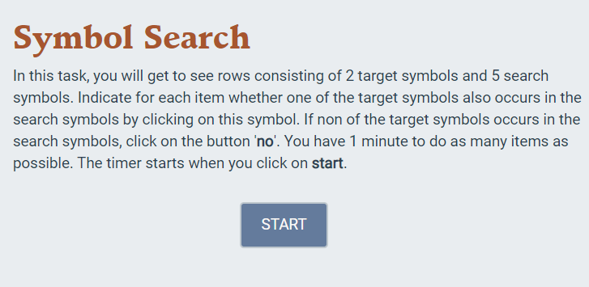

When you click on start, the timer of one minute starts and you can make the given items as fast as possible.

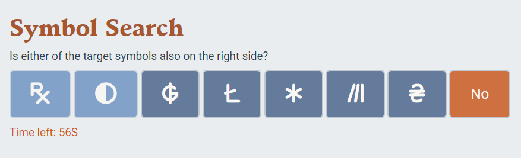

When you click on an item you are informed about whether or not the answer was correct.  
E.g., when you rightly click on the fifth button:

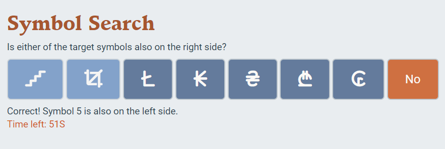

or, after having wrongly clicked on “no”:

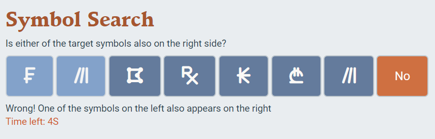

## End of the Search Task

### Reason for End

There are two reasons that can end the search task, either the time runs out or all of the items have been completed. Either way, you’ll be presented with a pop-up screen that displays the reason for the end, the total number of items completed and the corresponding number of correct responses:

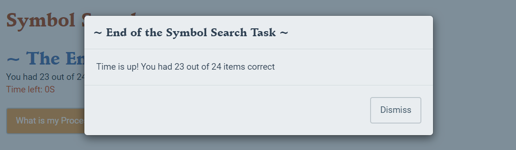

When the task ends the number of items you completed, the number of correct responses and the time you spend on the task are recorded, and you can choose to save them.

### Saving Data and Viewing Results:

Following the task completion, participants have the option to save their scores and view their performance relative to others by selecting the **save & see results** button.

### Plots

The Symbol-Search App incorporates various plot types to facilitate visualization of individual scores in comparison to those of previous participants. The application presents histograms displaying the distribution of previous scores, with the user’s score highlighted in orange. Users can choose from four distinct plot types:

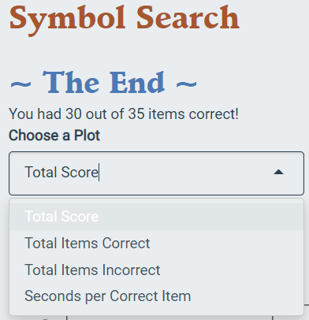

- **Total Score**: This plot calculates the total score by subtracting the number of incorrect items from the number of correct items. The scores for correct and incorrect items are adjusted to account for the total duration of one minute. If the task duration was longer or shorter than 60 seconds, the correct and incorrect scores are rescaled to reflect their values within a 60-second time-frame.

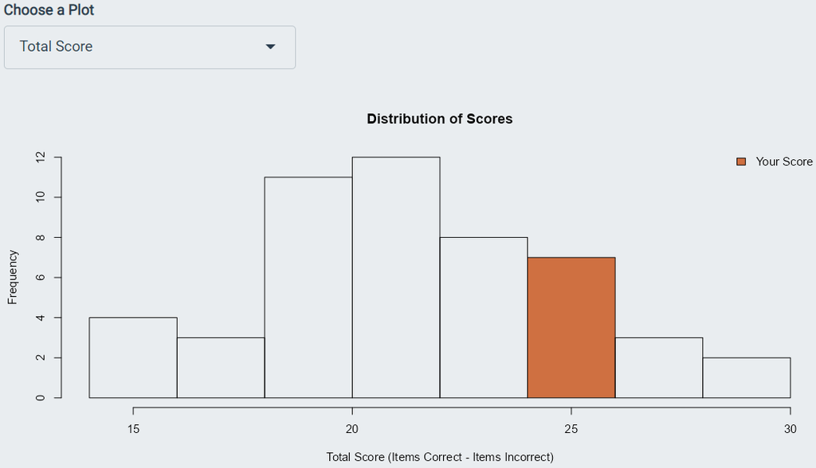

- **Total Items Correct** and **Total Items Incorrect** provide a scaled representation of the number of items answered correctly or incorrectly, respectively, relative to a one-minute duration.

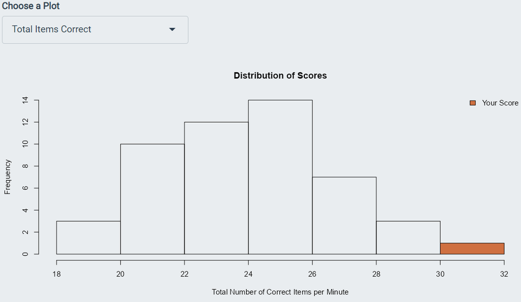

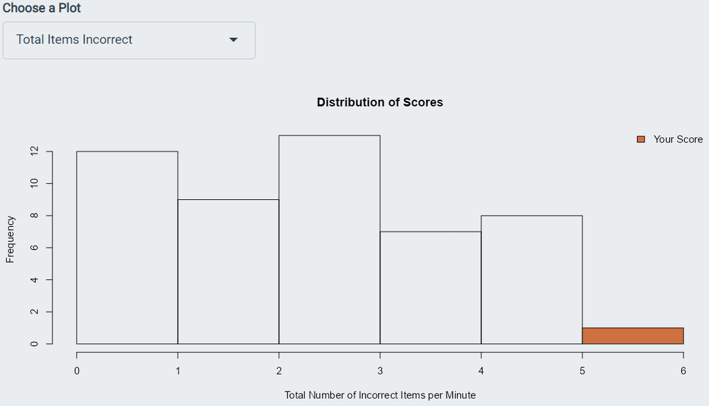

- **Seconds per Correct Item**: This plot shows the average number of seconds spent on each correct item.

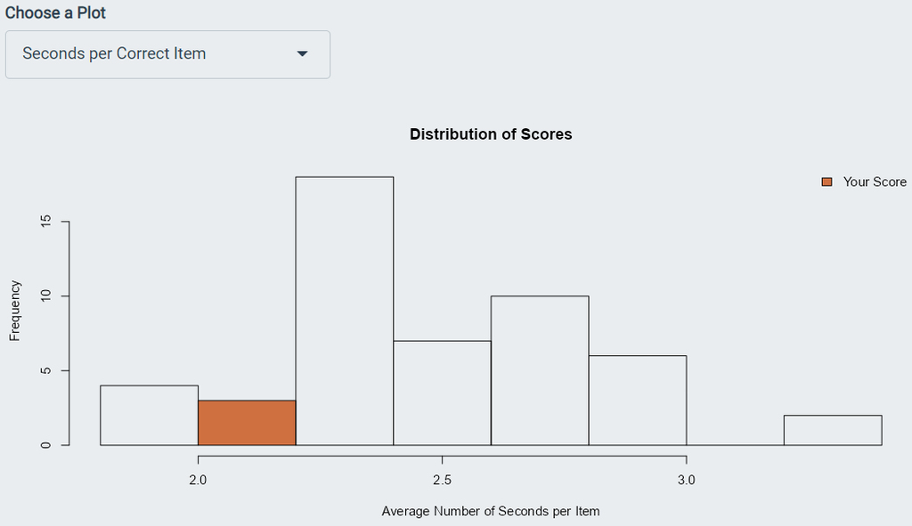